# BIOS 667 - Lecture 10: Residual Analyses and Diagnostics (Ch. 10)

Fitzmaurice, Laird & Ware (2011) - Applied Longitudinal Data Analysis

Naim Rashid

## Lecture Objectives

By the end of this lecture, you will be able to:

- Compute **raw** and **transformed (Cholesky-standardized)** residuals and explain why the transform decorrelates them
- Use the **Mahalanobis distance** $d_i = r_i^{*\top} r_i^{*}$ to flag outlying individuals
- Use the **semi-variogram of transformed residuals** to diagnose covariance misspecification
- Use random-effect (empirical BLUP) plots to spot **individuals with unusual profiles** (NOT to test RE normality)
- Read each diagnostic plot: what a good vs problematic pattern looks like

## Prerequisites / Recall

This lecture builds directly on two earlier ones.

| Recall from | What we reuse |
| --- | --- |
| **Ch. 7 (L07)** | Covariance pattern models; the marginal covariance $\Sigma_i = \operatorname{Cov}(\mathbf{Y}_i)$, with CS / AR(1) / unstructured forms |
| **Ch. 8 (L08)** | The LME $\mathbf{Y}_i = \mathbf{X}_i\boldsymbol\beta + \mathbf{Z}_i\mathbf{b}_i + \boldsymbol\varepsilon_i$, with $\Sigma_i = \mathbf{Z}_i G \mathbf{Z}_i^\top + R_i$, and REML estimation |

**Note**

Residual diagnostics ask: having fit a mean model $\mathbf{X}_i\boldsymbol\beta$ and a covariance model $\Sigma_i$, are BOTH adequate?

## Roadmap

| Part | Topic |
| --- | --- |
| 1 | Raw residuals, transformed residuals, Mahalanobis distance |
| 2 | The semi-variogram (covariance adequacy) |
| 3 | Worked Case Study: dental growth (real FLW data) |
| 4 | Software diagnostics in `nlme` / `lme4` (marginal vs conditional) |
| 5 | Beyond FLW Ch. 10: ACF, cluster influence, CUSUM |
| 6 | Practical checklist and pitfalls |

## Notation reference

| Symbol | Meaning |
| --- | --- |
| $Y_{ij}$ | response for subject $i$ at occasion $j$ (scalar) |
| $\mathbf{Y}_i$ | response vector for subject $i$ $(n_i \times 1)$ |
| $\mathbf{X}_i,\ \boldsymbol\beta$ | fixed-effect design $n_i \times p$ and coefficients |
| $\mathbf{Z}_i,\ \mathbf{b}_i$ | random-effect design and random effects, $\mathbf{b}_i \sim N(0, G)$ |
| $G$ | between-subject random-effects covariance (FLW’s letter, Ch. 8) |
| $R_i$ | within-subject residual covariance, $\boldsymbol\varepsilon_i \sim N(0, R_i)$ |
| $\Sigma_i = \mathbf{Z}_i G \mathbf{Z}_i^\top + R_i$ | marginal (total) covariance $\operatorname{Cov}(\mathbf{Y}_i)$ for subject $i$ |
| $\rho$ | correlation parameter (AR(1), exchangeable) |

Indices: $i$ subject $1,\dots,N$; $j$ occasion/time $1,\dots,n_i$ ($n$ when balanced); $k$ state (transition models); $g$ group. **Bold** = vector or matrix.

## Notation (this lecture)

| Symbol | Meaning |
| --- | --- |
| $r_i = \mathbf{Y}_i - \mathbf{X}_i\hat{\boldsymbol\beta}$ | raw (marginal) residual vector for subject $i$ |
| $L_i$ | lower-triangular Cholesky factor, $\hat\Sigma_i = L_i L_i^\top$ |
| $r_i^{*} = L_i^{-1} r_i$ | transformed residual (uncorrelated, unit variance) |
| $d_i = r_i^{*\top} r_i^{*}$ | Mahalanobis distance for subject $i$, $\approx \chi^2_{n_i}$ |
| $\gamma(h)$ | semi-variogram at time-lag $h$ |
| $r^{M}_{ij},\; r^{C}_{ij}$ | software residuals: marginal ($\mathbf{Y}-\mathbf{X}\hat\beta$) vs conditional ($\mathbf{Y}-\mathbf{X}\hat\beta-\mathbf{Z}\hat{\mathbf{b}}$) |

## Part 1: Raw, Transformed, and Outlier Diagnostics

## Why Diagnostics for LMMs?

Linear mixed-effects models rest on assumptions more complex than OLS.

| Assumption Category | What to Check |
| --- | --- |
| Mean structure | Is the form of $\mathbf{X}_i\boldsymbol\beta$ (e.g. linear time) adequate? |
| Covariance structure | Is $\Sigma_i$ (CS / AR(1) / RE structure) adequate? |
| Distribution | Approximate normality, no gross outliers |
| Outlying individuals | Subjects whose whole profile is unusual |

## Raw Residuals (FLW eq 10.1)

The raw (marginal) residual for subject $i$ is

$$r_i \;=\; \mathbf{Y}_i - \mathbf{X}_i\hat{\boldsymbol\beta}. \tag{10.1}$$

- One residual vector per subject, length $n_i$.
- If the mean model $\mathbf{X}_i\boldsymbol\beta$ is correct, these are centered at zero.
- **Problem:** raw residuals are *correlated* and have *unequal variances* (they inherit $\Sigma_i$), so ordinary regression diagnostics do not apply directly.

## Transformed Residuals (FLW eq 10.2)

Take the Cholesky factorization of the estimated marginal covariance, $\hat\Sigma_i = L_i L_i^\top$ ($L_i$ lower-triangular). Define

$$r_i^{*} \;=\; L_i^{-1} r_i \;=\; L_i^{-1}\!\left(\mathbf{Y}_i - \mathbf{X}_i\hat{\boldsymbol\beta}\right). \tag{10.2}$$

**Note**

The transformed residuals $r_i^{*}$ are **uncorrelated** and have **unit variance** - they mimic residuals from a standard linear regression.

- First element = standardized baseline residual.
- $k$-th element estimates $\dfrac{Y_{ik}-E(Y_{ik}\mid Y_{i1},\dots,Y_{i,k-1})}{\sqrt{\operatorname{Var}(Y_{ik}\mid Y_{i1},\dots,Y_{i,k-1})}}$.

## Mahalanobis Distance for Outlying Individuals (FLW eq 10.3)

A single summary of how far subject $i$’s whole profile is from its fitted values:

$$d_i \;=\; r_i^{*\top}\, r_i^{*}. \tag{10.3}$$

**Note**

Under a correctly specified model, $d_i \approx \chi^2_{n_i}$ ($n_i$ = number of repeated measures on subject $i$). Outlying individuals have **small p-values**.

- p-values give a *common metric* when $n_i$ varies across subjects.
- **Caution (FLW p.268):** because we focus on the most extreme $d_i$, the true tail behaves worse than a plain $\chi^2_{n_i}$; a Bonferroni correction ($p \times N$) is available but very conservative. Expect about $0.05N$ “significant” $d_i$ by chance.

## Part 2: The Semi-Variogram

## Variogram: FLW Definition (eq 10.4)

The semi-variogram is one-half the expected squared difference between two residuals on the **same** individual, at time-lag $h_{ijk}$:

$$\gamma(h_{ijk}) \;=\; \tfrac12\,\mathbb{E}\big[(r_{ij}-r_{ik})^2\big]. \tag{10.4}$$

Since residuals have mean zero,

$$\gamma(h_{ijk}) \;=\; \tfrac12\operatorname{Var}(r_{ij}) + \tfrac12\operatorname{Var}(r_{ik}) - \operatorname{Cov}(r_{ij},r_{ik}).$$

**Note**

**Key result.** Applied to the *transformed* residuals (variance 1, zero correlation), this becomes $\tfrac12(1)+\tfrac12(1)-0 = 1$. So under a correct covariance model the variogram of transformed residuals **fluctuates around 1** with no systematic curvature.

## Variogram: the Geostatistics Motivation (flagged)

**Warning**

**Beyond FLW Ch. 10 (motivation only).** In spatial / geostatistics, for a stationary process with process variance $\sigma^2$ and correlation function $\rho(u)$ at lag $u$,
$$\gamma(u) = \sigma^2\{1 - \rho(u)\}.$$
This is the Diggle et al. (2002) form. FLW *cites* this literature but does NOT use this expression in Ch. 10; its in-chapter rule is “transformed-residual variogram centers at 1.”

| Pattern (stationary motivation) | Implied correlation |
| --- | --- |
| Flat across lags | constant correlation (CS) |
| Rising toward $\sigma^2$ with lag | decaying correlation (AR(1)) |

## How to Read a Variogram

**Reading rule (transformed-residual scale)**

**Y-axis:** semi-variance $\gamma(h)$ (half mean squared difference of residuals at lag $h$). **X-axis:** time-lag $h$.

| Pattern You See | What It Means | Model Implication |
| --- | --- | --- |
| **Flat, fluctuating around 1** | covariance model adequate | keep the model |
| **Rising with lag** | correlation decays but model assumes constant | switch CS to AR(1) / exponential |
| **Rising without bound** | long-range dependence unmodeled | add random slope or longer-range correlation |

## Part 3: Case Study (Real FLW Data)

## Case Study: Dental Growth Data

**Important**

**Instructor substitution.** FLW Ch. 10’s worked example is the menarche / percent-body-fat study (162 girls, MIT Growth & Development Study), which is **not** distributed with the course. We substitute the **dental growth** data (Potthoff & Roy 1964; the Ch. 5/7/8 running example) and carry the identical Ch. 10 workflow end to end.

- 27 children (11 girls, 16 boys), distance (mm) from pituitary to pteryomaxillary fissure at ages 8, 10, 12, 14.
- Fit the Ch. 8 LME, then: **transformed residuals -> Mahalanobis outlier scan -> semi-variogram**.

## Case Study: Load and Reshape

```r
suppressPackageStartupMessages({
  library(nlme); library(ggplot2); library(dplyr)
})

# Download fallback (FLW site); local copy preferred
data_file <- "../../data/dental.txt"
if (!file.exists(data_file)) {
  dir.create("../../data", showWarnings = FALSE, recursive = TRUE)
  download.file("https://content.sph.harvard.edu/fitzmaur/ala2e/dental.txt",
                data_file)
}

# FLW dental.txt has a comment-header block and is WIDE (one row per child)
raw <- readLines(data_file)
dat_lines <- grep("^[[:space:]]*[0-9]+[[:space:]]+[FM]", raw, value = TRUE)
wide <- read.table(text = dat_lines, header = FALSE,
                   col.names = c("id", "gender", "age8", "age10", "age12", "age14"))

# reshape WIDE -> LONG
long <- reshape(wide, varying = c("age8", "age10", "age12", "age14"),
                v.names = "distance", timevar = "age",
                times = c(8, 10, 12, 14), idvar = "id", direction = "long")
long <- long[order(long$id, long$age), ]
long$id    <- factor(long$id)
long$age_c <- long$age - 8          # center at first occasion
head(long, 6)
```

## Case Study: Load and Reshape

```
     id gender age distance age_c
1.8   1      F   8     21.0     0
1.10  1      F  10     20.0     2
1.12  1      F  12     21.5     4
1.14  1      F  14     23.0     6
2.8   2      F   8     21.0     0
2.10  2      F  10     21.5     2
```

## Case Study: Fit the Ch. 8 LME

```r
fit <- lme(distance ~ age_c * gender,
           random = ~ 1 + age_c | id,
           data = long, method = "REML")
round(fixef(fit), 3)
```

```r
VarCorr(fit)
```

## Case Study: Fit the Ch. 8 LME

```
id = pdLogChol(1 + age_c)
            Variance   StdDev    Corr
(Intercept) 3.23395963 1.7983213 (Intr)
age_c       0.03252416 0.1803446 -0.091
Residual    1.71620491 1.3100400
```

## Case Study: Fit the Ch. 8 LME

[output not shown]

## Case Study: Transformed Residuals (eq 10.2)

```r
uids   <- levels(long$id)
r_marg <- resid(fit, level = 0)          # RAW residual Y - X*beta (level=0)
long$r_marg <- r_marg

long$r_star <- NA_real_
d_i <- setNames(numeric(length(uids)), uids)   # Mahalanobis distances

for (u in uids) {
  idx   <- which(long$id == u)
  Sig_i <- getVarCov(fit, individual = u, type = "marginal")[[1]]  # Sigma_i hat
  L_i   <- t(chol(Sig_i))                # lower-triangular: Sigma_i = L_i L_i'
  r_i   <- long$r_marg[idx]
  rstar <- solve(L_i, r_i)               # r* = L_i^{-1} r_i   (eq 10.2)
  long$r_star[idx] <- rstar
  d_i[u] <- sum(rstar^2)                 # d_i = r*' r*        (eq 10.3)
}

c(var_transformed = round(var(long$r_star), 3))   # should be ~1
```

## Case Study: Transformed Residuals (eq 10.2)

```
var_transformed
          0.972
```

## Case Study: QQ Plot of Transformed Residuals

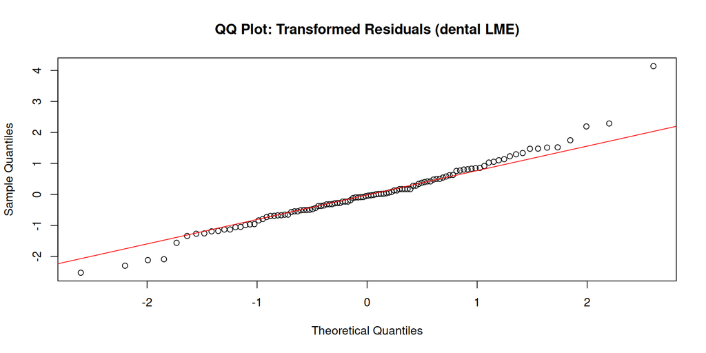

**Reading rule**

**Straight line** = approximate normality, model adequate. **Bow shape** = skewness. **Stragglers at the ends** = candidate outliers (here, the upper tail bends out, flagging an unusual observation - which the Mahalanobis scan localizes next).

## Case Study: Mahalanobis Outlier Scan (eq 10.3)

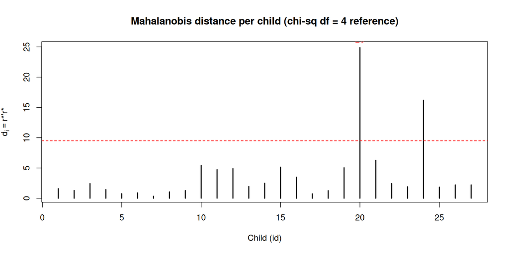

**Reading rule**

**Red line** = upper 5% point of $\chi^2_4$. Bars above it flag children whose whole profile fits poorly. Here 2 children cross p<0.05 (most extreme: id 20). Inspect, do not auto-delete; a few crossings are expected by chance ($\approx 0.05N$).

## Case Study: Semi-Variogram of Transformed Residuals (eq 10.4)

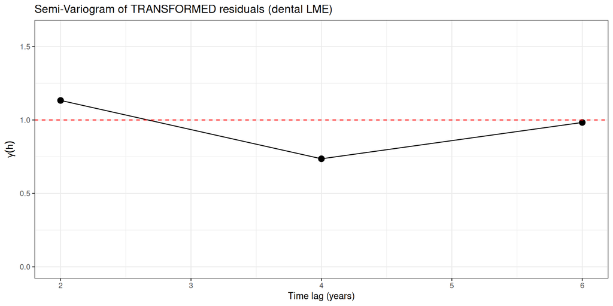

**Reading rule**

**Red dashed line at 1** = the FLW reference for transformed residuals. Points fluctuating around 1 with no systematic curvature = the random-intercept-plus-slope covariance is **adequate**. Drift away from 1 / curvature = wrong covariance model.

## Case Study: Does Dropping the Random Slope Change the Variogram? (dental)

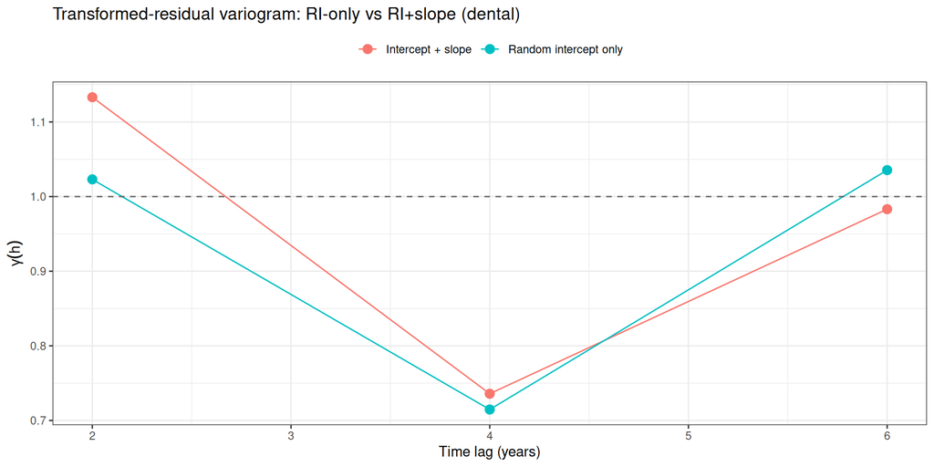

**Reading rule**

On dental the two transformed-residual variograms are **nearly identical** and both hover around the dashed line at 1 (range about 0.71-1.13, with a small-sample dip at the middle lag). So dropping the random slope barely changes the covariance fit here: the random-intercept structure is already close to adequate for these data. The pattern to watch for elsewhere is a variogram that drifts steadily **up and away from 1** (the simpler model’s would, if the dropped structure mattered) - dental does not show that.

## Case Study: Standalone SAS (PROC MIXED)

```sas
/* Dental growth LME with residual + influence diagnostics.
   Data already reshaped to LONG: id gender age_c distance.            */
proc mixed data=dental_long method=reml;
    class id gender;
    model distance = age_c gender age_c*gender /
          solution outpm=marg_resid outp=cond_resid
          residual influence(effect=id);
    random intercept age_c / subject=id type=un g;
run;

/* outpm= : marginal residuals (Y - X*beta)         -> variogram input
   outp=  : conditional residuals (Y - X*beta - Z*b)
   influence(effect=id) : leave-one-cluster-out Cook's D / restricted
                          likelihood distance per child (Level-2)       */
```

## Part 4: Software Diagnostics (`nlme` / `lme4`)

## Two Residual Types in Software

FLW’s split is raw vs transformed. Software (`nlme`, `lme4`) instead exposes two *levels* of residual. Keep the vocabulary distinct:

| Software residual | Formula | Use |
| --- | --- | --- |
| **Marginal** $r^{M}_{ij}$ | $Y_{ij} - X_{ij}\hat{\boldsymbol\beta}$ | mean / covariance adequacy (this is FLW’s *raw* residual) |
| **Conditional** $r^{C}_{ij}$ | $Y_{ij} - (X_{ij}\hat{\boldsymbol\beta} + Z_{ij}\hat{\mathbf{b}}_i)$ | within-subject error assumptions |

**Warning**

**`level` matters.** `residuals.lme()` defaults to the **innermost** level = **conditional** residuals ($Y - X\hat\beta - Z\hat{\mathbf b}$). For **marginal** residuals you must pass **`level = 0`**. (Direct analog of the `re.form = NA` trap.)

## Conditional Residuals vs Fitted

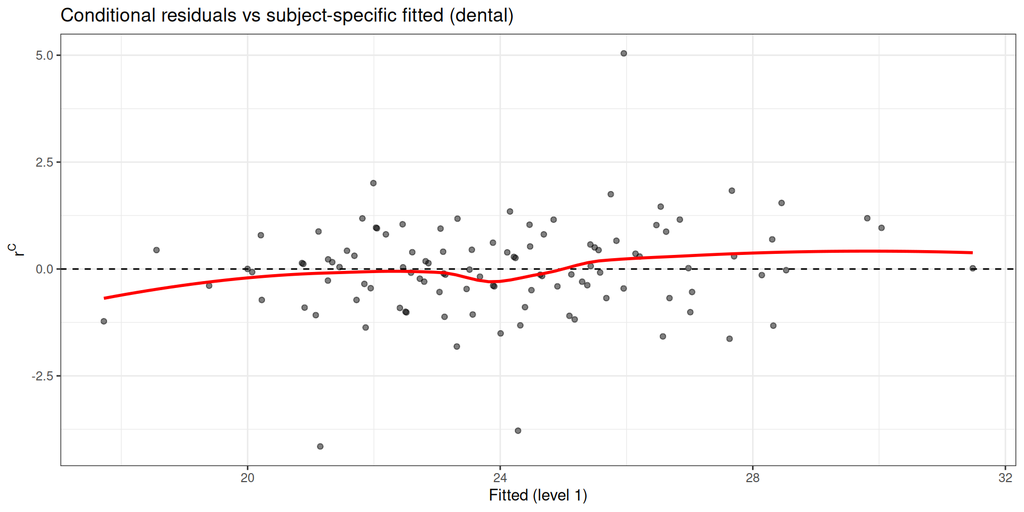

**Reading rule**

**Dashed line at 0** = target mean. Random scatter, constant spread = error assumptions OK. **Funnel / fanning** = non-constant variance. **Curvature in the red smooth** = mean model misspecified.

## Conditional Residual ACF (beyond FLW)

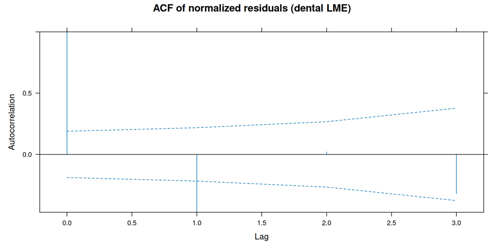

**Warning**

**Beyond FLW Ch. 10.** FLW diagnoses covariance adequacy with the semi-variogram of transformed residuals, NOT an ACF plot. `nlme::ACF` is a time-series convention shown here as a complementary software check.

## Random-Effect (Empirical BLUP) Plots: Correct Use

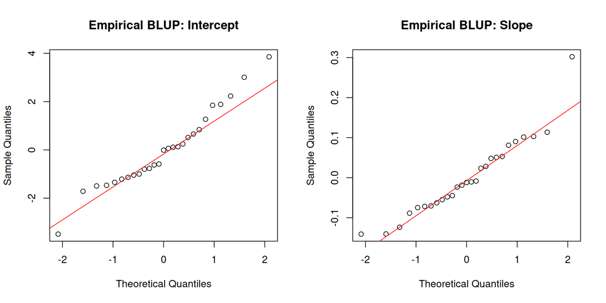

**Warning**

**FLW p.273 caution.** Do **NOT** use histograms / QQ plots of empirical BLUPs to judge the **normality of the random-effects distribution**. BLUPs are *shrunk* toward the population mean, so their spread understates the true RE variance.

**Reading rule**

Use these plots only to **spot individuals** with extreme/unusual subject-specific profiles (points far from the line), exactly as FLW does. A “non-normal looking” BLUP plot is NOT evidence the RE distribution is non-normal.

## Part 5: Beyond-FLW Diagnostics (flagged)

## Cluster Influence: Leave-One-Out Refit (beyond FLW)

```r
# REAL leave-one-cluster-out refit (N=27 children -> fast, runs in full)
beta_full <- fixef(fit)
ctrl  <- lmeControl(maxIter = 200, msMaxIter = 200, opt = "optim")
delta <- setNames(rep(NA_real_, length(uids)), uids)
for (u in uids) {
  sub <- long[long$id != u, ]
  rf  <- tryCatch(
    lme(distance ~ age_c * gender, random = ~ 1 + age_c | id,
        data = sub, method = "REML", control = ctrl),
    error = function(e) NULL)
  if (!is.null(rf)) delta[u] <- max(abs(fixef(rf) - beta_full))  # max |change|
}
delta <- delta[!is.na(delta)]   # drop any child whose deletion-refit failed
plot(seq_along(delta), delta, type = "h", lwd = 2,
     xlab = "Child (id) dropped", ylab = "max |delta beta|",
     main = "Leave-one-child-out: max |change| in fixed effects")
text(which.max(delta), max(delta), labels = names(which.max(delta)), pos = 3, col = "red")
```

**Warning**

**Beyond FLW Ch. 10** (instructor extension; see Pinheiro & Bates 2000, `influence.ME` for `lmer`). FLW’s in-chapter individual diagnostic is the **Mahalanobis distance** (Part 1), not deletion influence.

## Cluster Influence: Leave-One-Out Refit (beyond FLW)

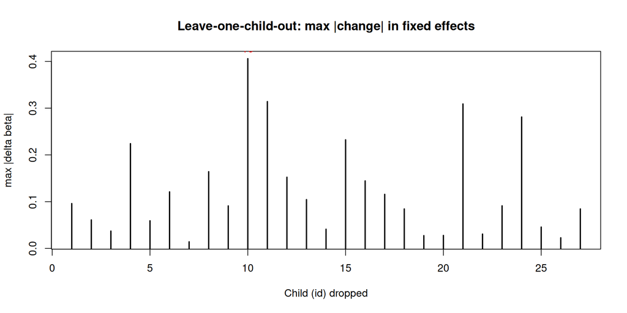

## CUSUM (recursive): beyond FLW (flagged)

```r
suppressPackageStartupMessages(library(strucchange))
# Recursive CUSUM is an OLS/structural-change construct -> run on an OLS fit
fm <- efp(distance ~ age_c + gender, type = "Rec-CUSUM", data = long)
plot(fm, main = "Recursive CUSUM (OLS mean model) - beyond-FLW demo")
```

**Warning**

**Beyond FLW Ch. 10** (Zeileis et al. `strucchange`, econometric structural-change literature). It is run on an **OLS** fit because recursive CUSUM is an OLS construct, and it assumes **ordered, independent** observations - which stacked longitudinal rows violate. Treat as illustrative only.

**Reading rule**

**Red boundary lines** = simulated null envelope. The empirical fluctuation process **crossing** the boundary flags a structural change in the mean over the ordering. Staying inside = no detected change.

## CUSUM (recursive): beyond FLW (flagged)

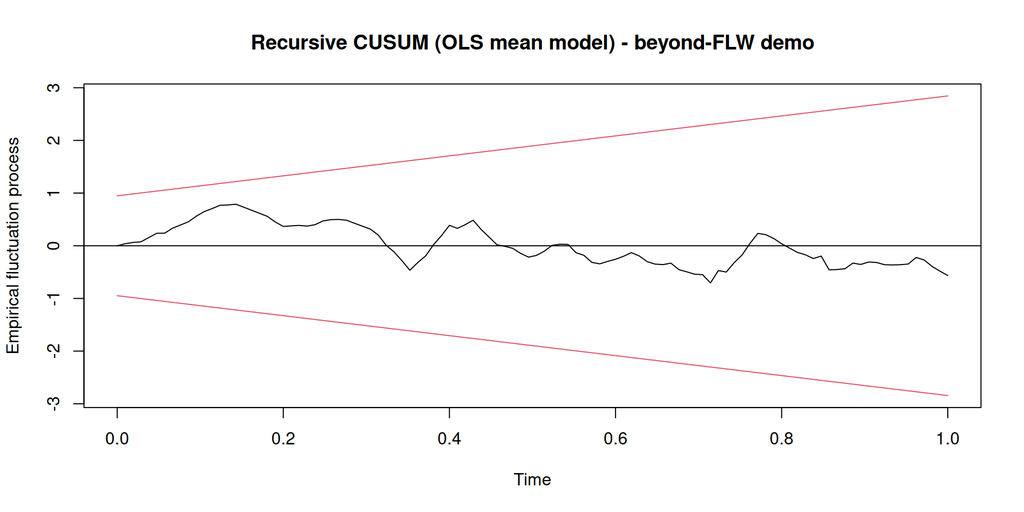

## What FLW Actually Does: Aggregated Sums (Section 10.4)

FLW Section 10.4 (“aggregating residuals”) uses the **Lin, Wei & Ying (2002)** cumulative / moving sums of *raw* residuals over a covariate $x_{ijk}$ or fitted value:

$$W_k(x) = \frac{1}{\sqrt{N}}\sum_{i=1}^{N}\sum_{j=1}^{n_i} I(x_{ijk}\le x)\, r_{ij}.$$

- Under a correct mean model, $W_k(\cdot)$ behaves like a **zero-mean Gaussian process**.
- Assess by **simulating** many null realizations and comparing the observed $\max|W_k|$ to the simulated maxima (a **supremum** test, p-value = proportion exceeding).
- **Robust:** valid regardless of the true covariance among responses.

## Part 6: Checklist and Pitfalls

## Practical Diagnostic Checklist (FLW Ch. 10)

| Step | Action |
| --- | --- |
| 1 | Compute **transformed** residuals $r_i^{*}=L_i^{-1}(\mathbf Y_i-\mathbf X_i\hat{\boldsymbol\beta})$ |
| 2 | QQ plot of $r_i^{*}$ (normality, stragglers) |
| 3 | **Mahalanobis** $d_i=r_i^{*\top}r_i^{*}\sim\chi^2_{n_i}$ to rank outlying individuals |
| 4 | **Semi-variogram** of transformed residuals: should center at 1 |
| 5 | Empirical-BLUP plots to **spot unusual individuals** (NOT to test RE normality) |
| 6 | Revise mean / covariance; re-check |

## RI vs RS: Comparison (boundary caveat)

| Model | Random Effects | When residuals/variogram suggest it |
| --- | --- | --- |
| RI | intercept only | flat residual variance, variogram near 1 |
| RS | intercept + slope | fanning vs time, variogram drifts off 1 under RI |

**Warning**

**Boundary / mixture caveat.** Testing whether the random slope is needed is a **variance-component-on-the-boundary** test. Dropping a random slope from a random-intercept model removes **TWO** parameters (the slope variance and its covariance with the intercept), so the LRT null is the **Stram-Lee mixture** $\tfrac12\chi^2_1 + \tfrac12\chi^2_2$ - **NOT** a simple halving of a single $\chi^2$.

## Common Mistakes to Avoid

**Important**

| Mistake | Why It Is Wrong | Correct Approach |
| --- | --- | --- |
| QQ-plotting RAW residuals | correlated, unequal variance | use TRANSFORMED residuals $r_i^{*}$ |
| `resid(fit)` assuming marginal | default is innermost = conditional | pass `level = 0` for marginal/raw |
| Variogram reference of “0 at lag 0” | wrong scale | transformed-residual variogram centers at **1** |
| BLUP QQ to test RE normality | shrinkage understates variance (FLW p.273) | use BLUP plots only to spot unusual individuals |
| Auto-deleting high-$d_i$ subjects | a few are expected by chance | investigate, run sensitivity analysis |
| Simple halving for RS LRT | drops TWO parameters | Stram-Lee $\tfrac12\chi^2_1+\tfrac12\chi^2_2$ |

## Diagnostic Decision Tree

**What Pattern Leads to What Fix?**

| You Observe | Most Likely Cause | Try This |
| --- | --- | --- |
| Fanning in residuals vs time | missing random slope | add a random slope `~ 1 + time` grouped by `id` (exact call in notes) |
| Transformed-residual variogram drifts off 1 | wrong covariance structure | switch CS to AR(1), or add random slope |
| ACF lag-1 outside bands | residual autocorrelation - but first rule out a short-series normalization artifact (let the transformed-residual variogram be the primary check) | add the Ch. 7 AR(1) residual structure (`corAR1`, grouped by `id`; exact call in notes) **only if the variogram also signals misfit** |
| Bow / stragglers in transformed QQ | skew / outliers | inspect via Mahalanobis $d_i$ |
| Curvature in residuals vs fitted | misspecified mean | add polynomial / spline |
| High $d_i$ for a subject | outlying individual | investigate; sensitivity analysis |

## Diagnostic Principles Across Models

| Model | Residual to use | What to Check | Note |
| --- | --- | --- | --- |
| LMM (Ch. 8) | transformed $r_i^{*}$ | mean, variance, covariance | empirical-BLUP plots: spot individuals, not RE normality |
| Covariance pattern (Ch. 7) | transformed | covariance adequacy via variogram | assumes correct mean |
| GEE (Ch. 13, **preview**) | Pearson / deviance | mean, link, dispersion | working correlation is heuristic; valid SEs need MCAR (IPW-GEE for MAR) |
| Fixed effects (Ch. 9) | OLS residuals | standard OLS diagnostics | overfitting can mask issues |

## Check Your Understanding

**Pause and Reflect**

1. Why must we use TRANSFORMED residuals (not raw) for a QQ plot or variogram in a longitudinal model?
2. The transformed-residual variogram drifts upward away from 1. What does that signal?
3. A colleague QQ-plots the empirical BLUPs, sees curvature, and concludes the random effects are non-normal. Why is that conclusion unsafe?

**Answers:** (1) Raw residuals are correlated with unequal variances ($\Sigma_i$); only the Cholesky transform $r_i^{*}=L_i^{-1}r_i$ makes them approximately iid N(0,1), so the standard reference lines apply. (2) The covariance model is misspecified (the “good” reference for transformed residuals is a flat line at 1); consider AR(1) or a richer random-effects structure. (3) BLUPs are shrunk toward the population mean, so their distribution understates the true RE variance (FLW p.273); BLUP plots can only flag unusual individuals, not test RE normality.

## Summary

- **Raw residual** (eq 10.1) $r_i=\mathbf Y_i-\mathbf X_i\hat{\boldsymbol\beta}$ - correlated, unequal variance.
- **Transformed residual** (eq 10.2) $r_i^{*}=L_i^{-1}r_i$ - uncorrelated, unit variance; the chapter’s defining tool.
- **Mahalanobis** (eq 10.3) $d_i=r_i^{*\top}r_i^{*}\sim\chi^2_{n_i}$ flags outlying individuals.
- **Semi-variogram** (eq 10.4) of transformed residuals centers at **1** under a correct covariance model.
- Empirical-BLUP plots spot unusual individuals; they do NOT test RE normality (FLW p.273).
- ACF, cluster-influence, CUSUM are useful but **beyond FLW Ch. 10** (flagged).

## Further Reading

- **Fitzmaurice, Laird & Ware (2011),** *Applied Longitudinal Analysis*, 2nd ed., **Chapter 10** (Residual Analyses and Diagnostics).
- **Lin, Wei & Ying (2002),** “Model-checking techniques based on cumulative residuals,” *Biometrics* 58, 1-12 (FLW’s aggregated-residuals method).
- **Pinheiro & Bates (2000),** *Mixed-Effects Models in S and S-PLUS* (`nlme` residual / `Variogram` / `ACF` tooling).
- **Verbeke & Molenberghs (2000)** and **Diggle et al. (2002)** for the geostatistics variogram (nugget / sill).

**Note**

**Assessment:** this material is examined in **HW4** (residual diagnostics; covariance-structure adequacy via transformed-residual variograms; outlier scans).